# generate_spacebreak examples

Clay Morrow

7/14/2022

```r
library(breakR)
library(dplyr)
```

```r
library(ggplot2)
```

# Component functions

## Piecewise time series

In order to facilitate time-dependent trends, `breakR` uses piecewise time series functions to generate temporal data. The way these functions are created are with breakpoint data frames, generated with `break_frame()`. For example, if we want a time series from 0 to 10, with an increasing trend from 0-5 and a decreasing trend from 5-9, we would use the following code and resulting breakpoint data frame:

```r
(break.df <- break_frame(nodes = c(0, 5, 9), slopes = c(.2, -.2)))
```

```
##   segment left right start end slope
## 1       1    0     5     0 1.0   0.2
## 2       2    5     9     1 0.2  -0.2
```

To build the piecewise function from this output, the `breakwise()` function is used. Here, we’ll evaluate the piecewise function for each of the ten time points (0-9).

```r
(f.t <- breakwise(0:9, break.df))
```

```
##  [1] 0.0 0.2 0.4 0.6 0.8 1.0 0.8 0.6 0.4 0.2
```

And here’s what that looks like as a time series plot:

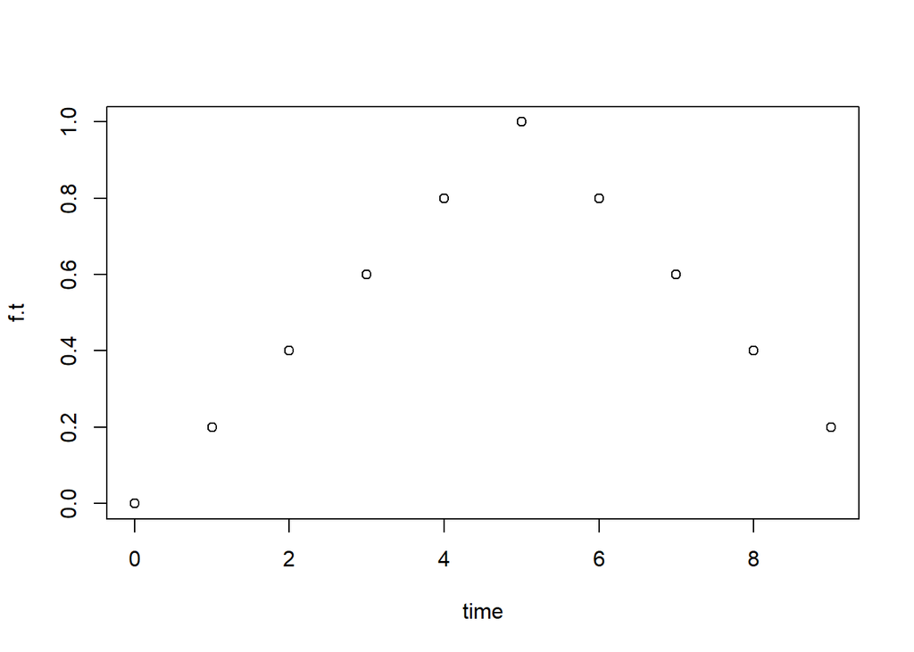

```r
plot(x = 0:9, y = f.t, xlab = 'time')
```

With these functions, we can make simple trends:

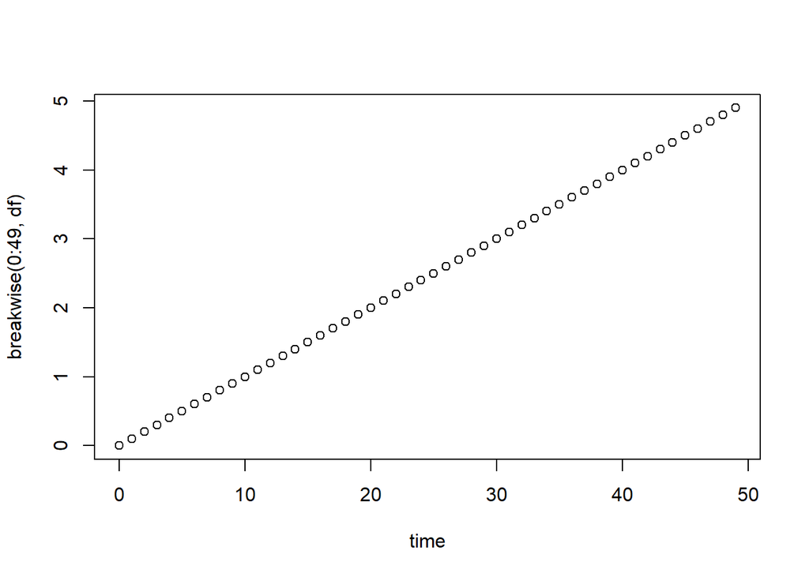

```r
df = break_frame(nodes = c(0, 49), slopes = .1)
plot(x = 0:49, y = breakwise(0:49, df), xlab = "time")
```

or very complicated time series with multiple breakpoints:

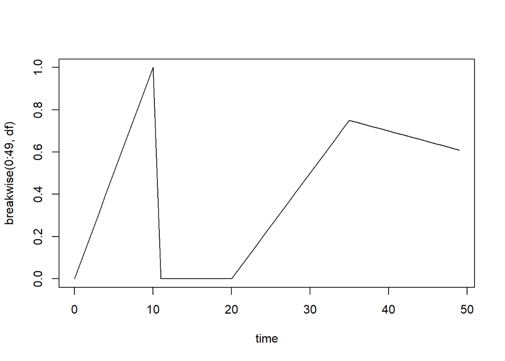

```r
df = break_frame(nodes = c(0, 10, 11, 20, 35, 49), slopes = c(.1, -1, 0, .05, -.01))
plot(x = 0:49, y = breakwise(0:49, df), type = "line", xlab = "time")
```

## Seasonality

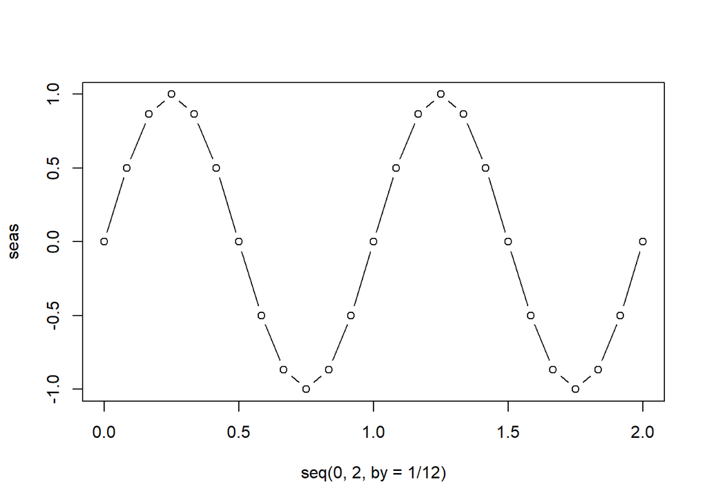

```r
seas = season(t = seq(0, 2, by = 1/12), amp = 1, per = 1)
plot(y = seas, x = seq(0, 2, by = 1/12), type = "b")
```

And we can even add random variation to this pattern:

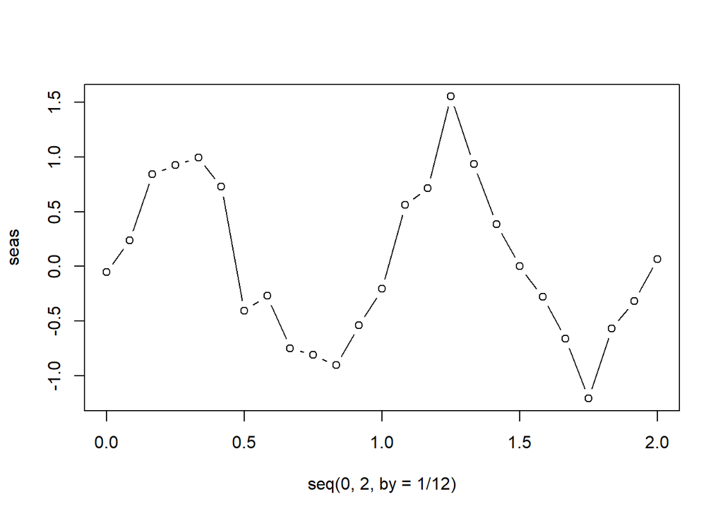

```r
seas = season(t = seq(0, 2, by = 1/12), amp = 1, per = 1, noise.sd = .2)
plot(y = seas, x = seq(0, 2, by = 1/12), type = "b")
```

## Piecewise functions with seasonality

Making a time trend with seasonality is as simple as adding these functionalities together.

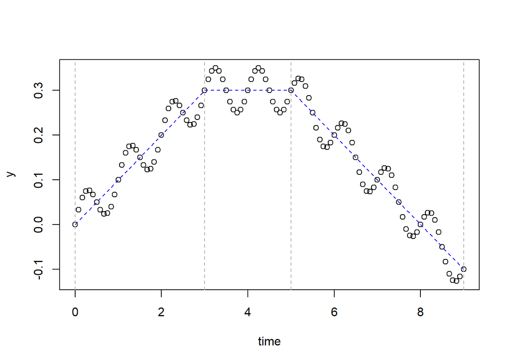

```r
time = seq(0, 9, by = 1/12)
breaks = c(0, 3, 5, 9)
df = break_frame(nodes = breaks, slopes = c(.1, 0, -.1))
f.t = breakwise(time, df)
seas = season(t = time, amp = .05, per = 1)
y = f.t + seas

plot(y = y, x = time)
lines(x = time, y = f.t, lty = 2, col = "blue")
abline(v = breaks, lty = 2, col = "grey70")
```

## Spatial variation

```r
space = generate_spcov(map.dims = c(3, 3), covar.pars = list(range = 1))
```

This function creates spatial coordinates for all the pixels:

```r
space$coord.df
```

```
##   pixel coords.x coords.y
## 1     1      0.0      0.0
## 2     2      0.5      0.0
## 3     3      1.0      0.0
## 4     4      0.0      0.5
## 5     5      0.5      0.5
## 6     6      1.0      0.5
## 7     7      0.0      1.0
## 8     8      0.5      1.0
## 9     9      1.0      1.0
```

a distance matrix:

```r
round(space$D.mat, 1)
```

```
##     1   2   3   4   5   6   7   8   9
## 1 0.0 0.5 1.0 0.5 0.7 1.1 1.0 1.1 1.4
## 2 0.5 0.0 0.5 0.7 0.5 0.7 1.1 1.0 1.1
## 3 1.0 0.5 0.0 1.1 0.7 0.5 1.4 1.1 1.0
## 4 0.5 0.7 1.1 0.0 0.5 1.0 0.5 0.7 1.1
## 5 0.7 0.5 0.7 0.5 0.0 0.5 0.7 0.5 0.7
## 6 1.1 0.7 0.5 1.0 0.5 0.0 1.1 0.7 0.5
## 7 1.0 1.1 1.4 0.5 0.7 1.1 0.0 0.5 1.0
## 8 1.1 1.0 1.1 0.7 0.5 0.7 0.5 0.0 0.5
## 9 1.4 1.1 1.0 1.1 0.7 0.5 1.0 0.5 0.0
```

and a covariances matrix:

```r
round(space$covar.mat, 1)
```

```
##     1   2   3   4   5   6   7   8   9
## 1 1.0 0.6 0.4 0.6 0.5 0.3 0.4 0.3 0.2
## 2 0.6 1.0 0.6 0.5 0.6 0.5 0.3 0.4 0.3
## 3 0.4 0.6 1.0 0.3 0.5 0.6 0.2 0.3 0.4
## 4 0.6 0.5 0.3 1.0 0.6 0.4 0.6 0.5 0.3
## 5 0.5 0.6 0.5 0.6 1.0 0.6 0.5 0.6 0.5
## 6 0.3 0.5 0.6 0.4 0.6 1.0 0.3 0.5 0.6
## 7 0.4 0.3 0.2 0.6 0.5 0.3 1.0 0.6 0.4
## 8 0.3 0.4 0.3 0.5 0.6 0.5 0.6 1.0 0.6
## 9 0.2 0.3 0.4 0.3 0.5 0.6 0.4 0.6 1.0
```

A random spatial variable can be created with `rnorm_spcor()`. We can use the covariance structure created above to create 5 random samples for each pixel.

```r
rnorm_spcor(n = 5, covar = space$covar.mat)
```

```
##               [,1]       [,2]       [,3]        [,4]        [,5]
##  [1,] -1.052914436 -1.0742793  1.1118502 -0.67095072  0.43559811
##  [2,] -1.457627977 -2.3801987  0.2333426 -0.49214099 -0.15755106
##  [3,]  0.193144829 -0.5823985 -0.8039862 -0.02924953 -0.52296995
##  [4,] -1.038393801 -1.4036206 -0.1783417 -0.48512154  0.68012328
##  [5,] -1.689772672 -1.7000408  0.3019564 -2.00814340  0.39646186
##  [6,] -0.474801736 -0.7818676  0.3263120 -1.36903044  0.02468724
##  [7,]  0.004903839  0.1094968 -0.7015438 -0.77432812 -0.10065951
##  [8,]  0.771307916 -0.8836126 -1.1327547 -0.40447476  0.15904508
##  [9,]  0.437095620 -0.1319153 -0.9502305 -0.27550578 -0.56749775
```

## Spatiotemporal data

And finally, we can generate a spatiotemporal variable with the `sparima_sim()` function. Here, we create a spatiotemporal variable with 20% AR(1) temporal autocorrelation, and the spatial covariance generated earlier, over 6 time points:

```r
(spacetime = sparima_sim(ntime = 6, covar = space$covar.mat, model = list(ar = .2)))
```

```
##               [,1]         [,2]      [,3]       [,4]     [,5]      [,6]
##  [1,] -1.102518457 -0.625853761 1.0998947  0.3269899 1.822236 1.5536527
##  [2,] -0.127069463 -0.173124787 0.8242444  1.2091934 2.058899 0.9568591
##  [3,] -0.817431106 -0.683639911 1.6904662 -0.6776215 1.789746 0.6933632
##  [4,] -1.466689229 -0.009710431 0.8695086  1.0471200 2.249378 1.3962519
##  [5,]  0.037838496 -0.354933836 0.1028916  1.4491500 2.816782 1.6822868
##  [6,]  0.479641011 -0.413990978 0.7348068  1.3817450 3.069515 2.1606714
##  [7,]  0.187469098 -0.584503639 1.3791306  0.1727135 1.281208 1.2043766
##  [8,] -0.824576460 -0.341577861 0.5403747  0.4430945 1.200668 2.0758079
##  [9,] -0.001581806  0.333439980 1.4744779  0.5317077 2.341324 3.3380854
```

This is what those data look like visually:

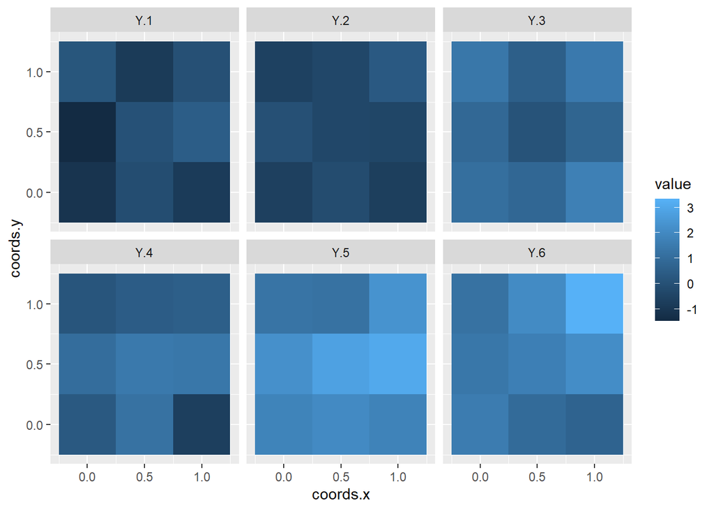

```r
data.frame(space$coord.df, Y = spacetime) %>%
  reshape2::melt(id.vars = c("pixel", "coords.x", "coords.y")) %>%
  ggplot(aes(x = coords.x, y = coords.y, fill = value)) +
  geom_tile() +
  facet_wrap(~variable)
```

And here they are when we add an underlying trend to the data:

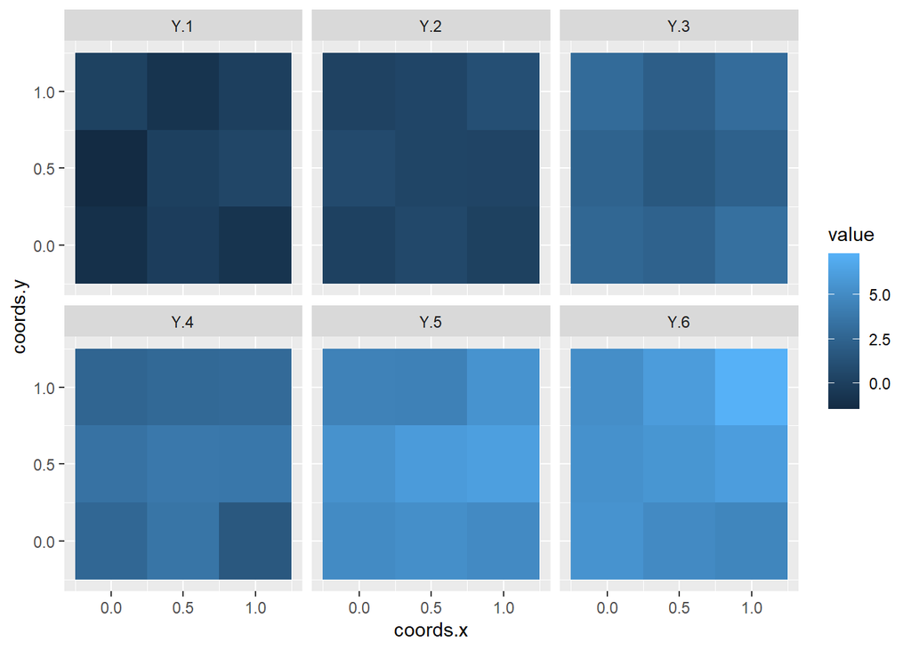

```r
st.trend = t(apply(spacetime, MARGIN = 1, FUN = function(x){x + .8*0:5}))

data.frame(space$coord.df, Y = st.trend) %>%
  reshape2::melt(id.vars = c("pixel", "coords.x", "coords.y")) %>%
  ggplot(aes(x = coords.x, y = coords.y, fill = value)) +
  geom_tile() +
  facet_wrap(~variable)
```

## Main simulation function

# 1. Stable (undisturbed) systems

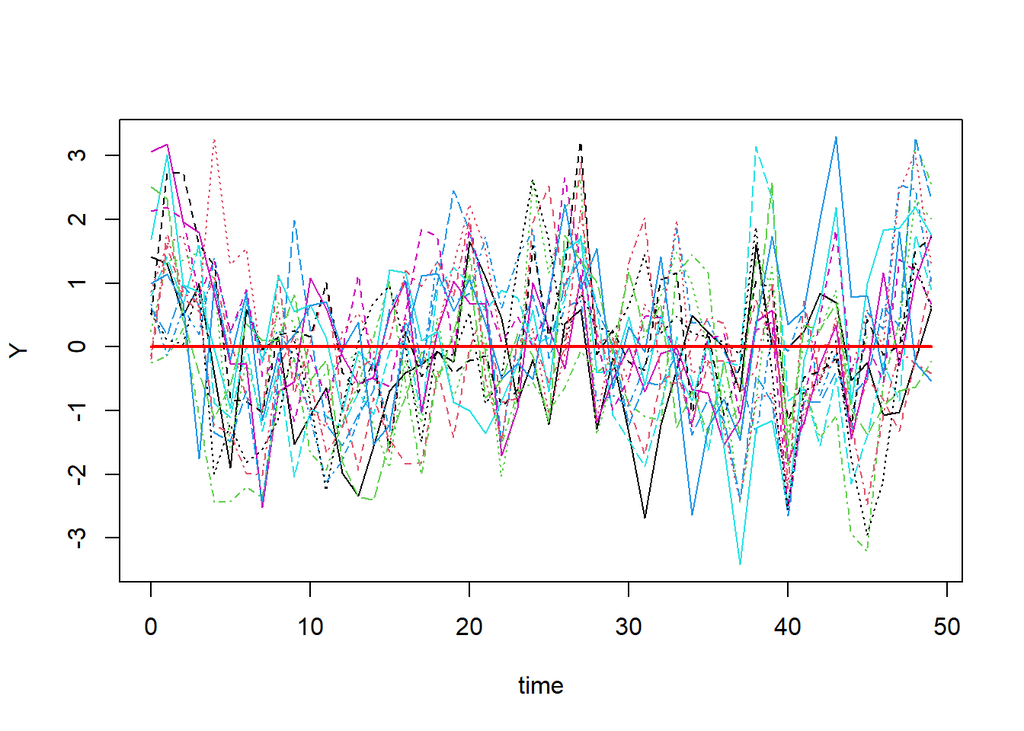

```r
bdf.1 <- break_frame(nodes = c(0, 49), slopes = c(0))
sb.1 <- generate_spacebreak(map.dims = c(4, 4), ntime = 50, break.df = bdf.1,
                            covar.pars = list(range = .5),
                            arima.mod = list(ar = .5),
                            sd = 1)

## each pixel through time, with overall trend
breakR:::plot.spacebreak(sb.1)
```

```r
# Note that the initial values are much more variable than the others,
# when sd is very low, this is because the burn.in in sparima_sim (and arima.sim)
# is not working as expected.
```

## 1b (with a trend)

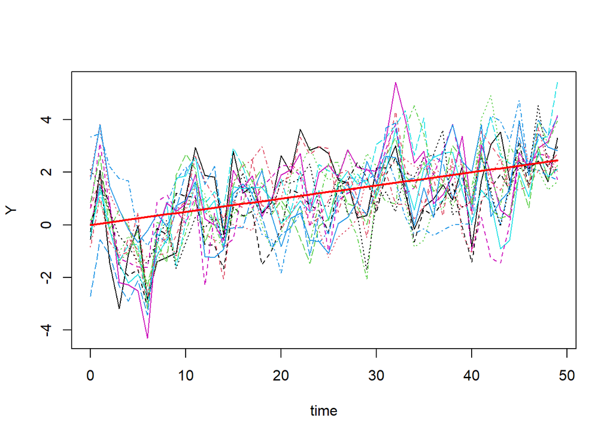

```r
bdf.1b <- break_frame(nodes = c(0, 49), slopes = c(.05))
sb.1b <- generate_spacebreak(map.dims = c(4, 4), ntime = 50, break.df = bdf.1b,
                            covar.pars = list(range = .5),
                            arima.mod = list(ar = .5),
                            sd = 1)

## each pixel through time, with overall trend
breakR:::plot.spacebreak(sb.1b)
```

# 2. Seasonal changes

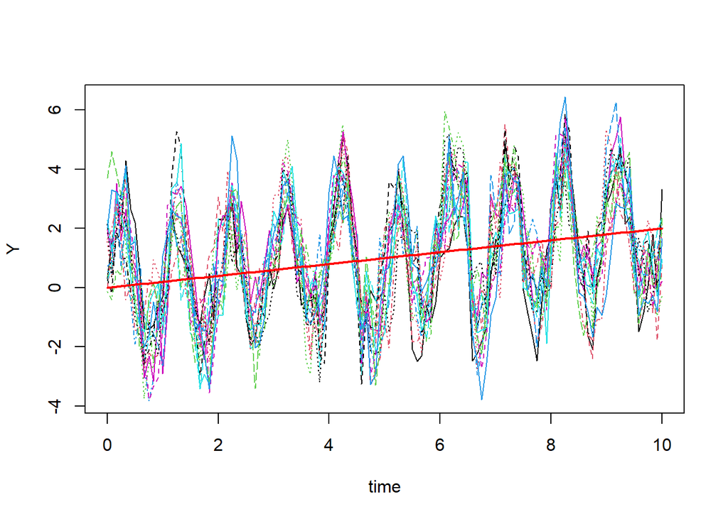

```r
bdf.2 <- break_frame(nodes = c(0, 10), slopes = c(0.2))
sb.2 <- generate_spacebreak(map.dims = c(4, 4), break.df = bdf.2,
                            covar.pars = list(range = .5),
                            arima.mod = list(ar = .5),
                            sd = 1,
                            seasonality = list(amp = 2, per = 1),
                            times = seq(0, 10, by = 1/12))

## each pixel through time, with overall trend
breakR:::plot.spacebreak(sb.2)
```

# 3. Gradual changes

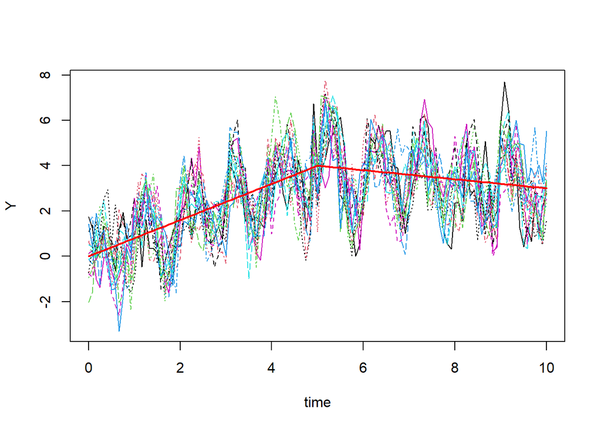

```r
bdf.3 <- break_frame(nodes = c(0, 5, 10), slopes = c(.8, -.2))
sb.3 <- generate_spacebreak(map.dims = c(4, 4), break.df = bdf.3,
                            covar.pars = list(range = .5),
                            arima.mod = list(ar = .5),
                            sd = 1,
                            seasonality = list(amp = 1.2, per = 1),
                            times = seq(0, 10, by = 1/12))

## each pixel through time, with overall trend
breakR:::plot.spacebreak(sb.3)
```

# 4. Abrupt changes

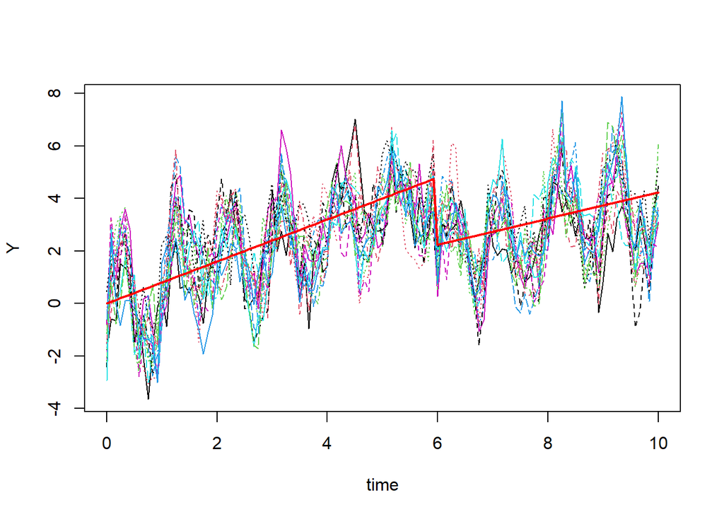

```r
bdf.4 <- break_frame(nodes = c(0, 6 - (1/12), 6, 10), slopes = c(.8, -30, .5))
sb.4 <- generate_spacebreak(map.dims = c(4, 4), break.df = bdf.4,
                            covar.pars = list(range = .5),
                            arima.mod = list(ar = .5),
                            sd = 1,
                            seasonality = list(amp = 1.2, per = 1),
                            times = seq(0, 10, by = 1/12))

## each pixel through time, with overall trend
breakR:::plot.spacebreak(sb.4)
```

# Simulate multiple maps and apply fitting functions:

Here, I’ll use the same parameters from the “Abrupt Changes” example above, to simulate 3 different maps and apply a fit function to each map.

In this example, we’ll create our fit function with a simple linear model and a mixed effects model. However, users interested in breakpoint analyses will need to write a function that contains each of the breakpoint methods to be tested. Here is that example fit function:

```r
example_fitfun_map <- function(Y, ...){
  # convert Y (matrix) into a long-form dataframe
  data = melt_spacebreak(Y)

  ## fit the models of interest
  model.lm <- stats::lm(value ~ time, data = data) # linear
  model.lmer <- lme4::lmer(value ~ (1|time), data = data) #random effects
  ## any other model that you want goes here ...

  # return the model outputs, even if they differ.
  output <- list(lm = model.lm, lmer = model.lmer)
}
```

Now we’ll simulate the 3 maps:

```r
sims <- simulate_spacebreak(nmaps = 3, map.dims = c(4, 4), break.df = bdf.4,
                            covar.pars = list(range = .5),
                            arima.mod = list(ar = .5),
                            sd = 1,
                            seasonality = list(amp = 1.2, per = 1),
                            times = seq(0, 10, by = 1/12),
                            fit_FUN = example_fitfun_map)
```

And show a simple output of the results by plotting each of the 3 maps, including the true trends in red and the fitted model from the simple regression case:

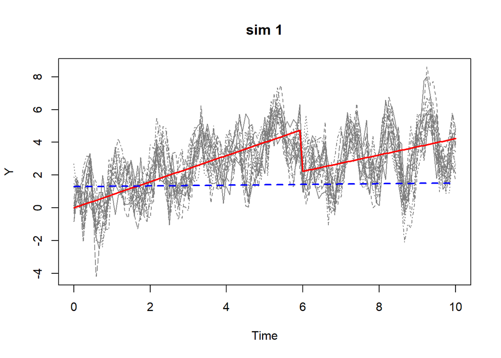

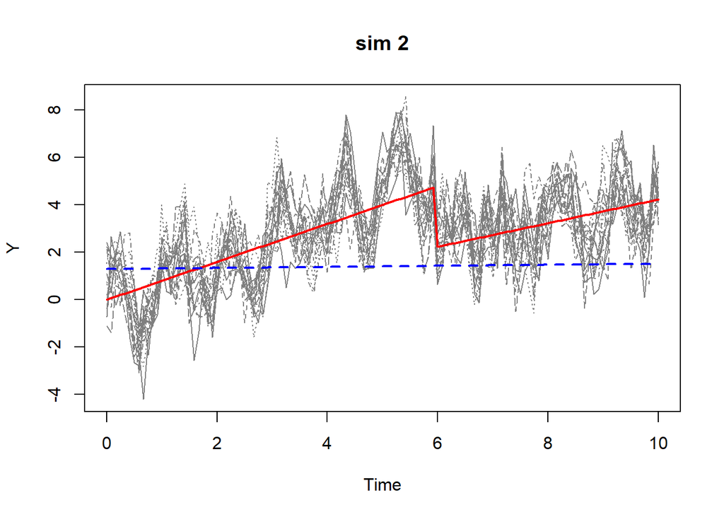

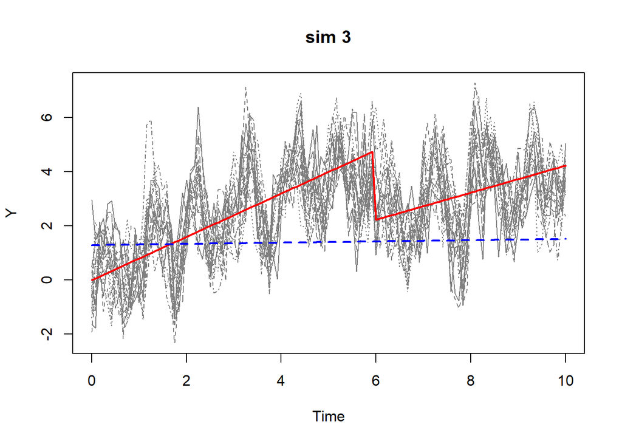

```r
for(i in seq_len(length(sims$data))){
  matplot(y = t(sims$data[[i]]), x = sims$time, type = "l", ylab = "Y", xlab = "Time", col = 'grey50',
          main = paste("sim", i))
  lines(sims$f.t ~ sims$time, col = "red", lwd = 2) # true slopes

  ## add in linear slope from model
  lines(predict(sims$fits[[1]]$lm, newdata = data.frame(time = sims$time)) ~ sims$time, col = "blue", lty = 2, lwd = 2)
}
```

The linear model does a poor job of approximating the true trends - as expected.